# cv

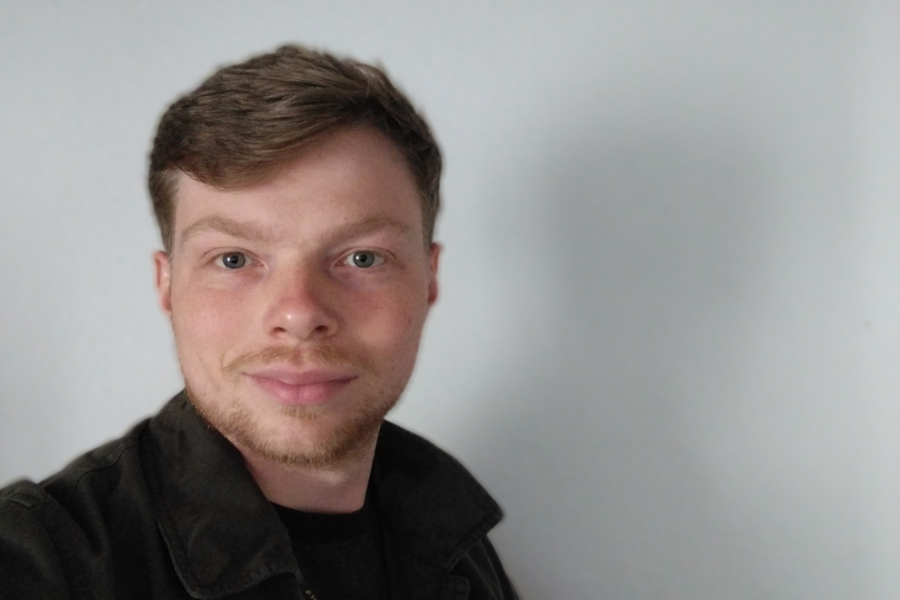

## Vita

Patrick Zerrer has been working as a research assistant at the Center for Media, Communication and Information Research since April 2020. In the Laboratory for Digital Communication and Information Diversity, under the direction of Prof. Dr. Cornelius Puschmann, he is dedicated to the systematic investigation of digital media use using quantitative and automated methods (CSS, R, scraping, mobile tracking, etc.).

From December 2017 to February 2020, Patrick Zerrer worked as an assistant at the Institute of Communication Science in Jena as part of a DFG project. The research project focused on the investigation of deliberative interactions in online user comments. In his role as a research assistant, Patrick actively supported the data collection and analysis.

Prior to his current position, Patrick earned his Master of Arts in Public Communication at the Friedrich Schiller University Jena from October 2017 to February 2020. He deepened his interest in social, sociological and political topics during his studies at the University of Passau, where he studied Governance and Public Policy – Political Science from September 2013 to September 2017 and graduated with a Bachelor of Arts.

## Curriculum Vitae

Since April 2020  
**Centre for Media, Communication and Information Research (ZeMKI)**  
*Research associate*  
Lab: Digital communication and information diversity

October 2017 until February 2020  
**Friedrich Schiller University Jena**  
*Master’s degree in Public Communication, Master of Arts*

September 2013 until September 2017  
**University of Passau**  
*Study programme in the field of Governance and Public Policy - Political Science, Bachelor of Arts degree*